# Hw4_RNA Seq

Tanubrata Dey

4/3/2021

```r
library(dplyr)
library(biomaRt)
library(edgeR)
library(limma)
```

## Know your data

The data is retrieved from [GEO dataset](https://www.ncbi.nlm.nih.gov/geo/query/acc.cgi?acc=GSE84271). From the information provided in the website and/or the original article where the dataset was reported, answer the following questions:

1. What is the sample? Include the species and cell type. This information tells you the reference genome that should be used and allows you to expect the expression of certain genes in experiments properly performed. (3%)

Tissues from embryonic spinal cord. Mus musculus (mouse). Examination of embryonic spinal cord motor neurons expression in thoracic and brachial levels. Control and Pbx mutant.

2. What is the protocol/reagent used to amplify the cDNA and generate the library? This information is usually provided in the pages for individual samples but not in the main page. It allows you to select the adapter and primer sequences to use when trimming the data. (3%)

cDNA was amplified using Nugene’s Ovation RNA-Seq System V2 kit (Part No. 7102).amplified for 10 cycles of PCR.

3. What is the read length? With the growing popularity of long-read sequencing technique, it is also important to know which platform was used to sequence the samples. (3%)

The samples were mixed into two pools and run on two 50-nucleotide paired end read rapid run flow cell lanes with the Illumina HiSeq 2500 sequencer. Generating on average 74 and 101 million reads passing filter for brachial and thoracic samples respectively.

4. If the samples are sequenced with Illumina platform, are they pair-ended or single-ended? (3%)

pair-ended

5. Is the library strand-specific? This is dependent on the kit used to generate the library, so check the manufacturer’s website. (3%)

yes

## Alignment & read counting

You’ll need to submit the sbatch file for read mapping with `Kallisto` (5%) and the rate of pseudoalignment for each sample (can be found as `p_pseudoaligned` in `run_info.json`, 5%).

SRR3831024 : 53.6 SRR3831025 : 53.7 SRR3831026 : 52.9 SRR3831027 : 52.9 SRR3831028 : 53.7 SRR3831029 : 53.7 SRR3831030 : 55.9 SRR3831031 : 55.9 SRR3831032 : 57.2 SRR3831033 : 57.2 SRR3831034 : 53.4 SRR3831035 : 53.4

## Generate design matrix from metadata (5%)

In this assignment, we mainly care about differences between genotypes, so let’s generate a design matrix containing this information. See the lecture for details about a design matrix.

```r
x <- read.csv("metadata.csv")
x
```

```
##        run_id genotype biorep_id techrep_id
## 1  SRR3831024       WT         1          1
## 2  SRR3831025       WT         1          2
## 3  SRR3831026       WT         2          1
## 4  SRR3831027       WT         2          2
## 5  SRR3831028       WT         3          1
## 6  SRR3831029       WT         3          2
## 7  SRR3831030   PbxMut         1          1
## 8  SRR3831031   PbxMut         1          2
## 9  SRR3831032   PbxMut         2          1
## 10 SRR3831033   PbxMut         2          2
## 11 SRR3831034   PbxMut         3          1
## 12 SRR3831035   PbxMut         3          2
```

```r
a <- x$genotype

a_updated <- as.factor(a)
class(a_updated)
```

```
## [1] "factor"
```

```r
a_updated <- relevel(a_updated, "WT")

design <- model.matrix(~a_updated)
design
```

```
##    (Intercept) a_updatedPbxMut
## 1            1               0
## 2            1               0
## 3            1               0
## 4            1               0
## 5            1               0
## 6            1               0
## 7            1               1
## 8            1               1
## 9            1               1
## 10           1               1
## 11           1               1
## 12           1               1
## attr(,"assign")
## [1] 0 1
## attr(,"contrasts")
## attr(,"contrasts")$a_updated
## [1] "contr.treatment"
```

## Prepare gene-count matrix (10%)

```r
counts_tb <- read.csv("all_genes.csv", header=TRUE, sep=",")
```

```r
# Remove the version number
counts_tb$target_id <- gsub("\\..*", "", counts_tb$target_id)
```

### Convert the transcript ids to gene ids/symbols

```r
# Load the conversion table
txgtf <- readRDS("txkey.rds")
counts_tb <- merge(txgtf, counts_tb,
                   by.x = "transcript_id",
                   # In case your transcript name column is not target_id,
                   # you should change this line below
                   by.y = "target_id")

# Aggregate transcript counts from the same gene to get counts per gene
counts_gene <- group_by(counts_tb, gene_id) %>%
  dplyr::select(-transcript_id) %>%
  summarize_all(sum)



# Drop the gene id column
counts <- as.data.frame(counts_gene[ , -1])
row.names(counts) <- counts_gene$gene_id

head(counts)
```

```
##                    SRR3831024 SRR3831025  SRR3831026 SRR3831027 SRR3831028
## ENSMUSG00000000001 2060.00000 2078.00000 1864.000000 1907.00000 2186.00000
## ENSMUSG00000000003    0.00000    0.00000    0.000000    1.00000    0.00000
## ENSMUSG00000000028   21.93070   21.58044   19.467400   16.32843   18.94281
## ENSMUSG00000000031  141.00000  126.00050  163.000000  136.00002  157.99973
## ENSMUSG00000000037   67.99998   54.99992   36.000002   46.00000   39.99992
## ENSMUSG00000000049    0.00000    0.00000    1.999999    0.00000    0.00000
##                    SRR3831029 SRR3831030 SRR3831031 SRR3831032 SRR3831033
## ENSMUSG00000000001 2318.00000 2215.00000 2211.00000 2432.00000 2342.00000
## ENSMUSG00000000003    0.00000    0.00000    0.00000    0.00000    0.00000
## ENSMUSG00000000028   40.03030   28.56030   39.74010   21.67730   24.26331
## ENSMUSG00000000031  133.99989   48.00000   49.00002   47.00001   54.99996
## ENSMUSG00000000037   31.00001   53.99995   57.00005   49.00004   58.00000
## ENSMUSG00000000049    0.00000    0.00000    0.00000    0.00000    0.00000
##                    SRR3831034 SRR3831035
## ENSMUSG00000000001 2038.00000 2032.00000
## ENSMUSG00000000003    0.00000    0.00000
## ENSMUSG00000000028   32.46651   39.35420
## ENSMUSG00000000031   51.00006   44.00000
## ENSMUSG00000000037   54.00001   50.00005
## ENSMUSG00000000049    0.00000    1.00000
```

### Convert Ensembl gene ids to Entrez/NCBI gene ids

```r
# Convert Ensembl ids to Entrez ids to allow GSEA and GO

## Establish connection with Ensembl, an online database
## and ask for mouse-related data
ensembl <- useMart("ensembl", dataset = "mmusculus_gene_ensembl")

## My Voom-processed object is called bra_v, and you'll need to edit.
## getBM performs batch query with your input value: row.names(bra_v)
## and retrieves the corresponding attributes from Ensembl
entrez_id <- getBM(
  # Attributes are the type of converted data
  attributes = c("entrezgene_id", "ensembl_gene_id"),
  # Filter is the type of input data
  filter = "ensembl_gene_id",
  # Values is the input data
  values = row.names(counts),
  # Mart is the conversion database by useMart()
  mart = ensembl
)


## Check the content of entrez_id by head()
## We are creating a named vector here, where the names are Ensembl ids
## and the values are Entrez ids
conv_dict <- entrez_id$entrezgene_id
names(conv_dict) <- entrez_id$ensembl_gene_id

## You can later use this to rename your DGEList
## row.names(dge) <- conv_dict[row.names(dge)]
## !!Do this after you are done with non-specific filtering!!
```

```r
head(entrez_id)
```

```
##   entrezgene_id    ensembl_gene_id
## 1         14679 ENSMUSG00000000001
## 2         54192 ENSMUSG00000000003
## 3         12544 ENSMUSG00000000028
## 4         14955 ENSMUSG00000000031
## 5        107815 ENSMUSG00000000037
## 6         11818 ENSMUSG00000000049
```

## Filter the sample & TMM normalization

```r
genelevel_counts <- counts
dge <- DGEList(counts=genelevel_counts)
dim(dge)
```

```
## [1] 50462    12
```

Please only keep genes with more than 1 CPM in at least 6 samples. What is the ratio of genes that are kept?

```r
isexpr <- rowSums(cpm(dge) > 1) >=6
sum(isexpr)/nrow(dge) #fraction of genes kept
```

```
## [1] 0.3460624
```

```r
dge <- dge[isexpr,,keep.lib.sizes=FALSE]
dim(dge)
```

```
## [1] 17463    12
```

```r
## !!Do this after you are done with non-specific filtering!!
row.names(dge) <- conv_dict[row.names(dge)]
```

## TMM normalization

```r
dge <- calcNormFactors(dge, method="TMM")
```

## Model mean-variance relationship with Voom

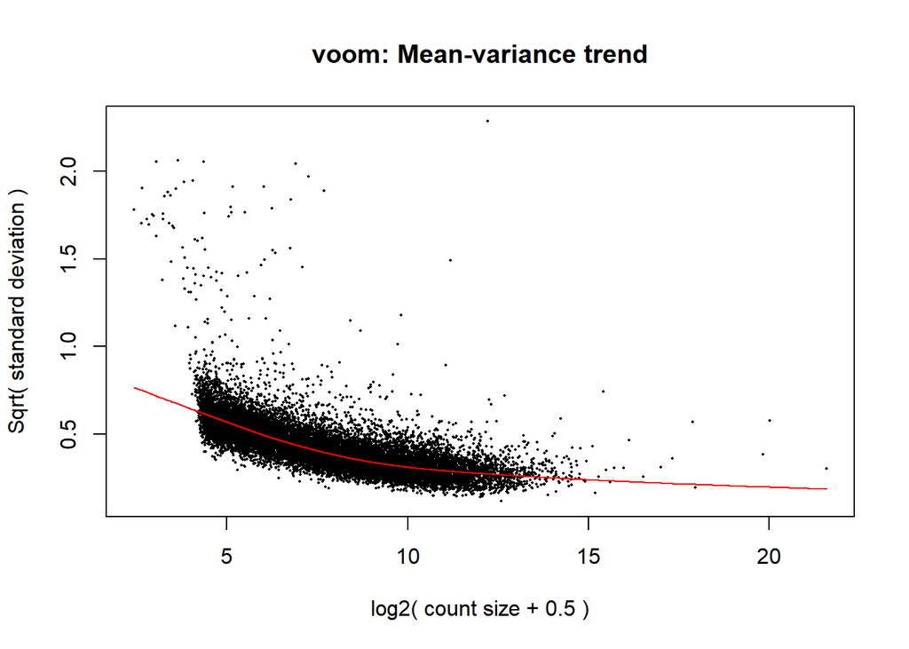

```r
v <- voom(dge,design,plot=TRUE)
```

### Plot an MDS plot to see observe the samples (5%)

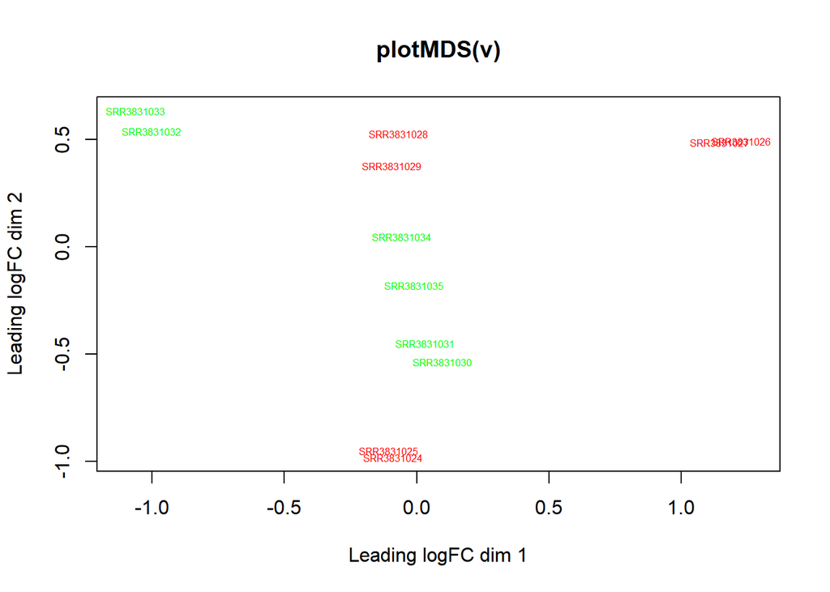

```r
plotMDS(v, main="plotMDS(v)",cex=0.5,col=c(rep("red",6),rep("green",6)))
```

```r
#plotMDS(v, main="plotMDS(v)",cex=0.5,col=c(rep("red",3),rep("green",3),rep("blue",3),rep("black",3)))
```

## Fit linear model and Naive Bayes model with Limma

```r
#linear model
fit <- lmFit(v,design)
```

```r
#ebayes stat
fit2  <- eBayes(fit)
colnames(fit2)
```

```
## [1] "(Intercept)"     "a_updatedPbxMut"
```

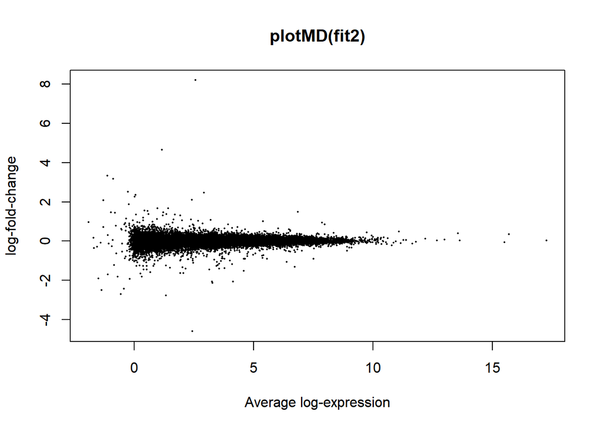

```r
#since plotMA and plotMD is the same thing, I did plotMD.
plotMD(fit2, main="plotMD(fit2)", cex=0.5, coef="a_updatedPbxMut")
```

### List top differentially expressed genes

After you are done with differential expression analysis, the list of differentially expressed genes can be retrieved with `topTable()`. Please save the differentially expressed genes that has an adjusted p-value < 0.05 as a csv file and submit it to NYU Classes.

```r
R_WT_vs_PbxMut = topTable(fit2, coef="a_updatedPbxMut", number=nrow(dge$counts))
```

```r
dim(R_WT_vs_PbxMut[R_WT_vs_PbxMut$adj.P.Val <= 0.05,])
```

```
## [1] 963   7
```

```r
head(R_WT_vs_PbxMut)
```

```
##           ID      logFC  AveExpr         t      P.Value    adj.P.Val        B
## 5051   18027 -1.0631667 6.392894 -15.70087 4.358467e-11 3.093644e-07 15.68081
## 10904 231991 -2.0741286 4.144532 -16.22962 2.652747e-11 3.093644e-07 15.31662
## 9977   12123 -2.0595264 3.256560 -14.88531 9.657761e-11 4.216337e-07 13.60702
## 3      14955 -1.6287961 2.059661 -15.49396 5.314627e-11 3.093644e-07 12.57487
## 7705  214058 -0.8538456 5.383847 -12.59544 1.124482e-09 3.272806e-06 12.51339
## 2968  246048 -1.0637840 3.461343 -12.77668 9.137781e-10 3.191461e-06 12.14726
```

```r
library(WriteXLS)
```

```r
sigGenes = list()
sigGenes[["R_WT_vs_PbxMut"]] = R_WT_vs_PbxMut

sigGenes_fdr05 = lapply(sigGenes, function(y) y[y[,"adj.P.Val"]<=0.05,])
lapply( sigGenes_fdr05, nrow)
```

```
## $R_WT_vs_PbxMut
## [1] 963
```

```r
#create excel file of differentially expressed genes
#WriteXLS("sigGenes_fdr05",ExcelFileName=paste("expression_genelevel_WT_vs_PbxMut.xls",  sep=""),row.names=T, FreezeRow=1,FreezeCol=1,AdjWidth=F)
```

### GSEA

```r
load(file="mouse_H_v5p2.rdata")
```

```r
C2t <- ids2indices(Mm.H, rownames(v))
```

```r
rr <- romer(v,C2t,design=design,contrast=2,nrot=1000)      # ideally, should do >= 1000 rotations
romerUP_rr=topRomer(rr,n=10,alt="up")
romerDN_rr=topRomer(rr,alt="down")
romerMIXED_rr=topRomer(rr,alt="mixed")
```

```r
romerUP_rr #top 10
```

```
##                                          NGenes          Up     Down
## HALLMARK_OXIDATIVE_PHOSPHORYLATION          232 0.000999001 1.000000
## HALLMARK_XENOBIOTIC_METABOLISM              194 0.000999001 1.000000
## HALLMARK_MYC_TARGETS_V2                      62 0.001998002 0.999001
## HALLMARK_REACTIVE_OXIGEN_SPECIES_PATHWAY     57 0.003996004 0.997003
## HALLMARK_ADIPOGENESIS                       244 0.003996004 0.997003
## HALLMARK_GLYCOLYSIS                         229 0.005994006 0.995005
## HALLMARK_MTORC1_SIGNALING                   254 0.024975025 0.976024
## HALLMARK_DNA_REPAIR                         181 0.027972028 0.973027
## HALLMARK_E2F_TARGETS                        248 0.030969031 0.970030
## HALLMARK_MYC_TARGETS_V1                     240 0.038961039 0.962038
##                                                Mixed
## HALLMARK_OXIDATIVE_PHOSPHORYLATION       0.006993007
## HALLMARK_XENOBIOTIC_METABOLISM           0.690309690
## HALLMARK_MYC_TARGETS_V2                  0.306693307
## HALLMARK_REACTIVE_OXIGEN_SPECIES_PATHWAY 0.000999001
## HALLMARK_ADIPOGENESIS                    0.218781219
## HALLMARK_GLYCOLYSIS                      0.000999001
## HALLMARK_MTORC1_SIGNALING                0.034965035
## HALLMARK_DNA_REPAIR                      0.021978022
## HALLMARK_E2F_TARGETS                     0.252747253
## HALLMARK_MYC_TARGETS_V1                  0.004995005
```

```r
romerDN_rr #bottom
```

```
##                                    NGenes        Up        Down       Mixed
## HALLMARK_IL2_STAT5_SIGNALING          219 0.9950050 0.005994006 0.739260739
## HALLMARK_ANDROGEN_RESPONSE            143 0.9940060 0.006993007 0.000999001
## HALLMARK_TNFA_SIGNALING_VIA_NFKB      203 0.9930070 0.007992008 0.134865135
## HALLMARK_ANGIOGENESIS                  34 0.9550450 0.045954046 0.862137862
## HALLMARK_COAGULATION                  104 0.9470529 0.053946054 0.955044955
## HALLMARK_UV_RESPONSE_DN               224 0.9450549 0.055944056 0.333666334
## HALLMARK_TGF_BETA_SIGNALING            77 0.9340659 0.066933067 0.562437562
## HALLMARK_INFLAMMATORY_RESPONSE        161 0.8991009 0.101898102 0.341658342
## HALLMARK_INTERFERON_ALPHA_RESPONSE     76 0.8491508 0.151848152 0.935064935
## HALLMARK_COMPLEMENT                   197 0.8211788 0.179820180 0.438561439
```

```r
romerMIXED_rr
```

```
##                                          NGenes          Up        Down
## HALLMARK_REACTIVE_OXIGEN_SPECIES_PATHWAY     57 0.003996004 0.997002997
## HALLMARK_GLYCOLYSIS                         229 0.005994006 0.995004995
## HALLMARK_ANDROGEN_RESPONSE                  143 0.994005994 0.006993007
## HALLMARK_MYC_TARGETS_V1                     240 0.038961039 0.962037962
## HALLMARK_OXIDATIVE_PHOSPHORYLATION          232 0.000999001 1.000000000
## HALLMARK_DNA_REPAIR                         181 0.027972028 0.973026973
## HALLMARK_APICAL_JUNCTION                    250 0.662337662 0.338661339
## HALLMARK_SPERMATOGENESIS                    156 0.341658342 0.659340659
## HALLMARK_HYPOXIA                            219 0.274725275 0.726273726
## HALLMARK_MTORC1_SIGNALING                   254 0.024975025 0.976023976
##                                                Mixed
## HALLMARK_REACTIVE_OXIGEN_SPECIES_PATHWAY 0.000999001
## HALLMARK_GLYCOLYSIS                      0.000999001
## HALLMARK_ANDROGEN_RESPONSE               0.000999001
## HALLMARK_MYC_TARGETS_V1                  0.004995005
## HALLMARK_OXIDATIVE_PHOSPHORYLATION       0.006993007
## HALLMARK_DNA_REPAIR                      0.021978022
## HALLMARK_APICAL_JUNCTION                 0.022977023
## HALLMARK_SPERMATOGENESIS                 0.032967033
## HALLMARK_HYPOXIA                         0.033966034
## HALLMARK_MTORC1_SIGNALING                0.034965035
```